# Homework #10 Solution

## 9 pts total

### A. 1 pt - Read in the [morphometric data from Barr, 2014](http://hompal-stats.wabarr.com/datasets/barr_astrag_2014.txt) on bovid astragali.

```r
astrag <- read.table("http://hompal-stats.wabarr.com/datasets/barr_astrag_2014.txt", header=TRUE, sep="\t")
head(astrag)
```

```
##   individual                 Taxon Habitat    ACF  APD     B DistRad DMTD
## 1  AMNH81690    Aepyceros_melampus      LC 384.72 6.89 15.16    9.22 1.78
## 2  AMNH82050    Aepyceros_melampus      LC     NA 6.09 14.00    8.73 1.64
## 3  AMNH83534    Aepyceros_melampus      LC     NA 6.14 17.22    9.19 1.70
## 4  AMNH85150    Aepyceros_melampus      LC     NA 5.80 15.27    8.85 1.72
## 5 AMNH233038 Alcelaphus_buselaphus       O 607.83 7.46 18.47   11.33 2.26
## 6  AMNH34717 Alcelaphus_buselaphus       O 465.91 6.56 15.47    9.79 1.78
##   DTArea   LML   MIN   MML PMTD ProxRad  PTArea   WAF   WAT
## 1 553.14 35.78 28.04 34.39 6.33   10.00  915.50 21.39 21.83
## 2 558.17 35.46 27.28 33.18 6.54   10.50  841.79 22.47 21.11
## 3 554.00 39.15 29.99 36.94 7.63   10.65  976.25 22.07 21.54
## 4 498.67 36.61 28.02 34.09 6.97   10.00  841.71 22.55 21.03
## 5 900.76 45.25 36.03 43.55 6.83   13.85 1557.05 28.98 27.07
## 6 649.47 36.81 30.80 35.95 4.28   10.91 1139.50 24.04 25.84
```

### B. 1 pt - Select the following colums from the data: `Taxon`, `B`, `DistRad`, and `Habitat`. Create a new dataframe with the `Taxon`, the `Habitat` and species means for `B` and `DistRad`.

```r
library(dplyr)
selectedAstrag <-
  astrag %>%
  select(Taxon, B, DistRad, Habitat) %>%
  group_by(Taxon) %>%
  summarise(B = mean(B), DistRad = mean(DistRad), Habitat=unique(Habitat))
```

### C. 1 pt - Read in [the ruminant phylogeny from Hernández Fernández & Vrba, 2007](http://hompal-stats.wabarr.com/datasets/ruminants.phy).

```r
#note I can load caper, which loads ape automatically and gives me access to the function read.tree()
library(caper)
rum <- read.tree("http://hompal-stats.wabarr.com/datasets/ruminants.phy")
rum
```

```
##
## Phylogenetic tree with 197 tips and 159 internal nodes.
##
## Tip labels:
##  Tragulus_javanicus, Tragulus_napu, Moschiola_meminna, Hyemoschus_aquaticus, Giraffa_camelopardalis, Okapia_johnstoni, ...
##
## Rooted; includes branch lengths.
```

### D. 1 pt - Combine the data and the tree using `comparative.data()` to ready the tree for pgls. *Note: if you used `dplyr` in the steps above, you need to change the class of the resulting dataframe, because there is a bug in `caper` and it won’t deal with a `dplyr` `tbl_df` object. You can use this line of code to fix it `class(dataframeFromDplyr) <- "data.frame"`*

```r
class(selectedAstrag) <- "data.frame"
compDat <- comparative.data(phy = rum, data = selectedAstrag, names.col = "Taxon")
```

### E. 2 pts - Plot the trimmed tree that includes just the taxa of interest in the astragalus dataset. Make it as beautiful as you can.

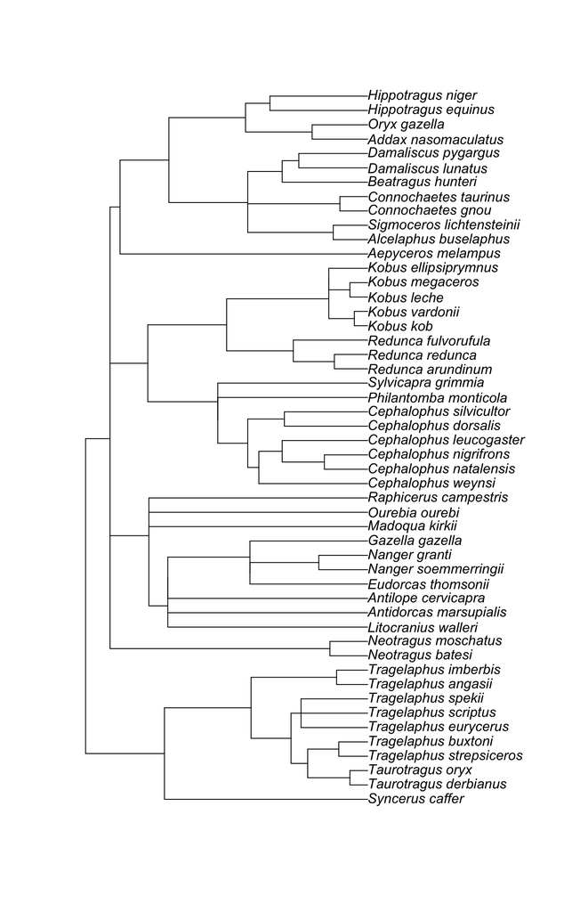

```r
plot(compDat$phy)
```

```r
summary(pgls(log(B)~log(DistRad) + sqrt(log(B) * log(DistRad)), data=compDat, lambda="ML"))
```

```
##
## Call:
## pgls(formula = log(B) ~ log(DistRad) + sqrt(log(B) * log(DistRad)),
##     data = compDat, lambda = "ML")
##
## Residuals:
##        Min         1Q     Median         3Q        Max
## -0.0032798 -0.0008363  0.0002625  0.0009896  0.0045782
##
## Branch length transformations:
##
## kappa  [Fix]  : 1.000
## lambda [ ML]  : 1.000
##    lower bound : 0.000, p = 2.5378e-06
##    upper bound : 1.000, p = 1
##    95.0% CI   : (0.727, NA)
## delta  [Fix]  : 1.000
##
## Coefficients:
##                              Estimate Std. Error t value Pr(>|t|)
## (Intercept)                  0.030289   0.011790   2.569  0.01344 *
## log(DistRad)                -1.260272   0.021212 -59.414  < 2e-16 ***
## sqrt(log(B) * log(DistRad))  2.235323   0.022748  98.265  < 2e-16 ***
## ---
## Signif. codes:  0 '***' 0.001 '**' 0.01 '*' 0.05 '.' 0.1 ' ' 1
##
## Residual standard error: 0.001507 on 47 degrees of freedom
## Multiple R-squared: 0.9995,  Adjusted R-squared: 0.9995
## F-statistic: 4.896e+04 on 2 and 47 DF,  p-value: < 2.2e-16
```

### G. 1 pt - Plot `log(B)` as a function of `log(DistRad)`, and color code the points by habitat type.

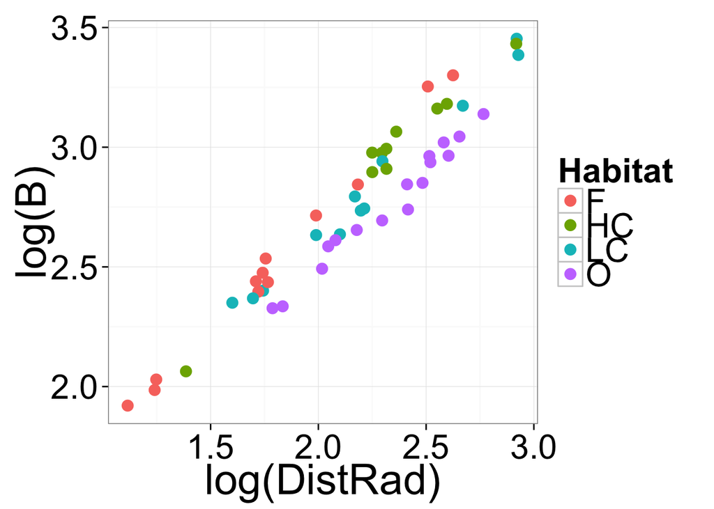

```r
library(ggplot2)
qplot(log(DistRad), log(B), data=compDat$data, color=Habitat, size=I(4)) + theme_bw(30)
```